# Organizing and Presenting Data as Figures

## Data

Understanding how data are generated, formatted for analysis, analyzed, and interpreted are increasingly important skills in a world flooded with information. Data can be interpreted many ways based on vaild logical thinking, our personal biases, and statistics. An old saying often misattributed to Mark Twain states,

> “There are three kind of lies: Lies, damned lies, and statistics…” ~ Multiple Sources

To properly interpret data it is important to first have a question to answer. Then, a plan how to collect data to answer the question and an analysis method that is appropriate. An appropriate data set will have controls or comparisons and collect data that is not biased toward one answer or another. The analysis method should be appropriate for the data set and not bias interpretations toward a single direction. Recognizing bias and identifying how they affect you interpretation of data are key traits of a good scientist.

## The Data Set

Many of the types of data that scientists in biology, health sciences and chemistry use are numbers, whether from spectroscopic analysis or based on assays of a solution such as blood. A well-organized data set has a number of characteristics:

- Clear labeling of variables
- Clear labeling of units where applicable
- Consistent variable use and naming scheme
- Single observations per variable (see examples below for clarification)
- Can be read by others easily.

Typically, numerical data are organized into a table like:

A data table with observations

| Time | Distance | Color |
| --- | --- | --- |
| 0 | 0 | blue |
| 5 | 4 | blue-ish |

However, even tables can be messy, so the first step after obtaining the data is to organize it. Below is a table that could use some cleaning before analysis:

A poorly formatted data table

| Car | Efficiency | Color | Type | Doors |
| --- | --- | --- | --- | --- |
| Toyota Highlander | 22 | Green | SUV | 4 |
| Ford Escape | 24 | Lime | Sport Utility | 4 + 1 |
| Mazda 6 | 29 | Forest Green | Car | 4 |
| Honda Prius | 43 mpg | Silver | Hybrid sedan | 4 |
| … | … | … | … | … |

In the table above, there are inconsistent naming schemes (Type and Color), multiple observations per variable (Car), unit-less numbers (Efficiency), and unclear naming scheme (Doors). Small issues like this are easy to fix and prevent misinterpretation later.

A better way to show the same data would be:

A better data table

| Brand | Model | Efficiency (mpg) | Color | Type of Car | Number of Entry Doors |
| --- | --- | --- | --- | --- | --- |
| Toyota | Highlander | 22 | Green | SUV | 4 |
| Ford | Escape | 24 | Green | SUV | 4 |
| Mazda | 6 | 29 | Green | Sedan | 4 |
| Honda | Prius | 43 | Silver | Sedan | 4 |
| … | … | … | … | … | … |

The goal of a table is to organize data in a way that comparisons across one or more catergories can be made efficiently. Be thinking as you are making the table not about how **you** understand the table but how your **reader** can understand the table. Good data tables can convey a lot of information faster than a paragraph of text and allow the reader to make comparisons of data quickly. However, for complex data, it may be easier to show the data as a figure.

## Plotting Data

A common phrase is:

> “A picture is worth a thousand words” ~ Multiple sources

This is true in science when presenting data in figure form. However, we all have seen poorly presenting figures that are more confusing than a thousand words of text. Therefore, a better statement might be a *good* picture says a thousand words. Below is an example of a data set where a table does not show the information well.

A large time series of data

| Time (seconds) | 0 | 10 | 30 | 60 | 90 | 100 | 250 | 500 | 1000 |
| --- | --- | --- | --- | --- | --- | --- | --- | --- | --- |
| 00 | 0.208 | 0.208 | 0.207 | 0.198 | 0.209 | 0.200 | 0.216 | 0.205 | 0.239 |
| 06 | 0.208 | 0.209 | 0.207 | 0.199 | 0.210 | 0.201 | 0.219 | 0.207 | 0.244 |
| 12 | 0.209 | 0.209 | 0.208 | 0.199 | 0.212 | 0.202 | 0.222 | 0.209 | 0.249 |
| 18 | 0.208 | 0.209 | 0.209 | 0.200 | 0.213 | 0.203 | 0.225 | 0.211 | 0.254 |
| 24 | 0.209 | 0.209 | 0.209 | 0.200 | 0.214 | 0.204 | 0.228 | 0.213 | 0.258 |

Besides the unit-less numbers in the columns, it is hard to make comparisons between data sets. A plot might be easier. Figure 1 shows much more clearly the individual data sets and indicates what the numbers mean so that comparisons and first analyses can occur.

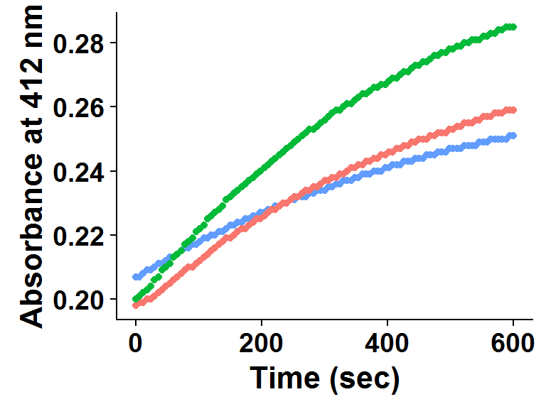

Plot of Absorbance vs. Time (sec)

Good figures have these elements:

- Labeled axes
- Units on numbers (where appropriate)
- Clear distinctions between data sets if multiple data sets are on the same figure
- Not too busy and only show one idea per figure

As you make figures, remember the idea of a figure is to convey a complex idea in a simple way. The reader does not know everything that occured nor have they seen your raw data. So use the figure to illustrate your data and analysis clearly.

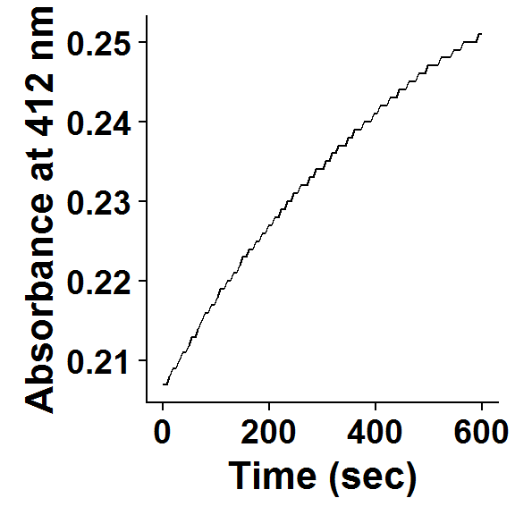

Fitted Plot of Absorbance vs. Time (sec)

Just like we saw how a figure can show data more effectively than a table in certain instances, the *type* of presentation matters as well. The time data shown in Figure 1 is numerical data over time and best represented as a scatter plot. The line plot shown in Figure 3 also works, however it does not show the raw data points and so trends and error are hard to see. The barplot in Figure 4 is non-sensical for these type of data.

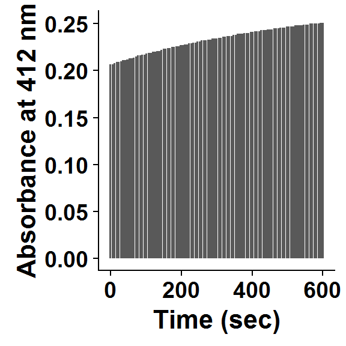

Fitted Plot of Absorbance vs. Time (sec)

For categorical types of data (meaning non-numerical like in certain columns of Tables 2 and 3), a barplot or boxplot showing the numbers of cars that are green versus silver might be more effective, while a scatter plot might be less effective. Choosing the right type of plot or representation can be hard and often requires making several versions of the plot before finding the one that *best* illustrates your main point.

Choosing the type of figure and parameters of that figure is where many students and scientists run into ethical issues. The representation that shows the largest difference may not be the most honest or best way to show data. The best resolution is to show your data in a way that conveys the most honest interpretation of the data, **DO NOT biase your reader with a figure that hides or exaggerates certain results.**

## Making Figures of Biomolecule Structures

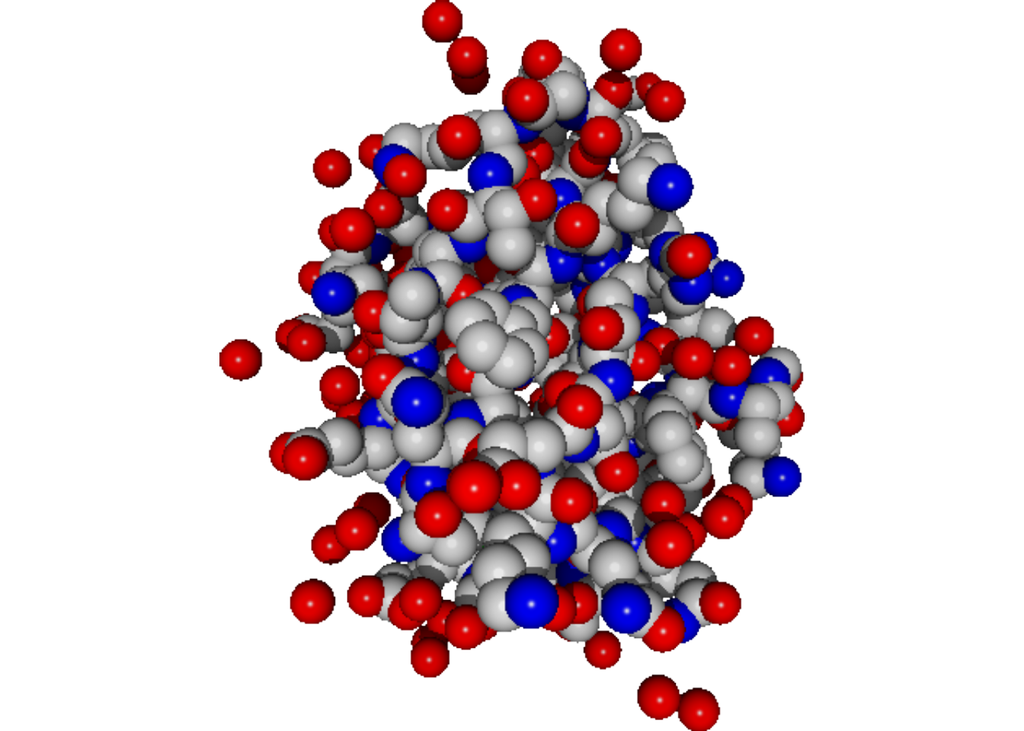

Uninformative Structure Figure

The first thing to decide when showing a figure is *Why am I showing this picture?* Often a figure is thrown in because protein structures look pretty and complex, however this is a mistake. A figure should **always** have a purpose.

Figure 6 is a bit better as it shows the secondary structure of the protein in distinct colors. Additionally, it shows a second image with a 180 degree rotation of the structure. Remember molecules are in three dimensions, therefore adding depth by showing a different angle helps the reader determine the relative position of the secondary structure.

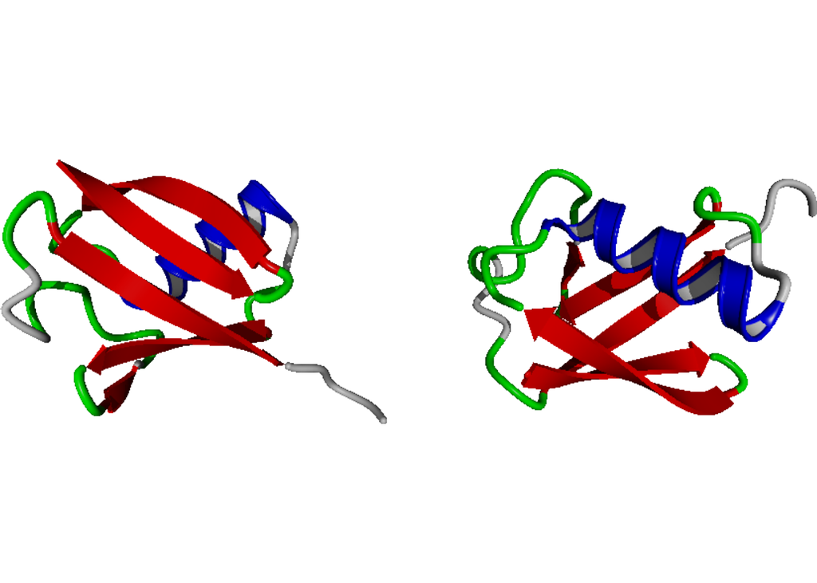

Figure showing Ubiquitin secondary structure

Beyond the secondary structure, Figure 6 shows us very little about specific features such as how amino acid side chains pack. If we were interested in a specific part of the protein, say the hydrophobic patch of ubiquitin, we could show the sidechains and use color or labels to highlight where it is. Figure 7 shows an example of a poorly highlighted structure and a well annotated structure. Notice in the right structure that the amino acids are colored distinctly and the side chains are shown. Moreover there is a label that is colored to highlight the target amino acids. This type detail seems like overkill but to a reader who does not have the background knowledge that you do, this is a helpful figure. Most molecule viewing programs offer an option to label points or add text. Taking the time to figure out how to add these features will pay off in clarity to your reader (and improve your grade!).

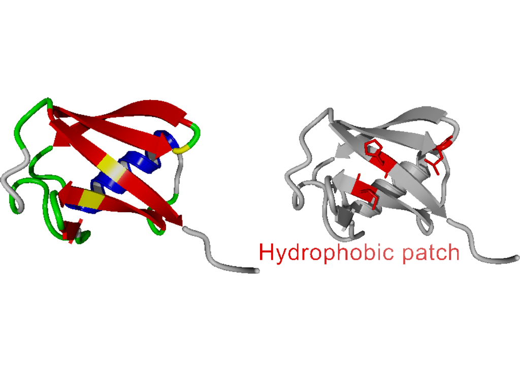

Annotating the hydrophobic patch

In closing, remember organizing data effectively makes it easy to analyze and present. The point of a data figure is to convey the data faithfully and to convey your findings. Sometimes, this requires tedious annotation of a picture, but that effort will pay off when your reader appreciates your findings and learns a new idea.

## More information and resources

[Fundamentals of Data Visualization by Claus Wilke](http://serialmentor.com/dataviz/)

Look at Data from [Data Visualization: A practical introduction](http://socviz.co/lookatdata.html#lookatdata)